# Delay discounting does not predict Body Mass Index: Supplementary Material

Megan Veillard

School of Social Sciences, University of Dundee, UK

Benjamin T. Vincent

School of Social Sciences, University of Dundee, UK

08 August 2019

This online supplementary material provides the code underlying the analyses as well as additional results to that presented in the main paper. Note that some results are conducted in JASP and tabular results are imported into this document. We reference to the corresponding JASP files (also available) where appropriate. Click the `code` boxes in order to see the r code underlying the analyses.

```r
library('tidyverse')
library('ggpubr')
library('psych')

apatheme = theme_bw(base_size = 12) +
  theme(panel.grid.major=element_blank(),
        panel.grid.minor=element_blank(),
        panel.border=element_blank(),
        axis.line=element_line(),
        text=element_text(family='Helvetica', size = 12),
        legend.background=element_blank())
```

# 1 Load and process data

```r
data <- read_csv('data/all_cleaned_scored.csv') %>%
  mutate(sex = factor(sex))

# Create dataframe just with the subset of participants interested in weight loss.
data_iiwl <- data[data$IWL == 'yes',]

# create sample size strings of "N=XXX" to use as information on the plots
n_all <- sprintf("N=%d", length(na.omit(data$logk_money)))
n_iiwl <- sprintf("N=%d", length(na.omit(data$logk_weight)))

# frequency of sex in the data
sex_freq <- count(data, sex)
n_female <- sex_freq$n[sex_freq$sex=='female']
n_male <- sex_freq$n[sex_freq$sex=='male']
```

When we closed the survey we had a total of 408 respondents. Because this was an unsupervised online questionnaire we took efforts to ensure the data quality was high. While the respondents were all unpaid volunteers, and therefore had some level of intrinsic motivation to complete the questionnaire accurately, we used fairly strict exclusion criteria. We first removed 22 participants on the basis of missing or incorrect responses, or who were under 18. We excluded one participant who did not disclose their sex assigned at birth. In the scoring procedure we calculated the number of responses correctly predicted by the hyperbolic discount function and corresponding discount tates. We removed participants where we were unable to predict 70% of more of their responses. This lead to 1 participant being exluded on the basis of the MCQ and 3 on the basis of the WCQ. We decided not to exclude participants who always chose the delayed reward. This is most likely due to the limited range of discount rates that the MCQ is sensitive to rather than aberrant responding.

After participant exclusion we have N=381 participants in total (242 female and 139 male). Of these, N=257 reported being interested in weight loss. Because all participants completed the MCQ, we calculated the $\log(k)$ for discounting of money for all N=381 participants. Only participants interested in weight loss completed the MCQ, so we were able to calculate the $\log(k)$ for discounting of weight loss for N=257 participants. Note that all log discount rates correspond to the natural logarithm.

# 2 Exploration of the dataset

## 2.1 Descriptive statistics

The output below shows some basic descriptive statistics of the key continuous variables of interest.

```r
# # select just the core variables of interest
# data %>%
#   select(age, bmi, logk_money, logk_weight, stunkard) %>%
#   psych::describe()

# temp <- data %>% select(sex, age, bmi, logk_money, logk_weight, stunkard)
# summary(temp)

data %>%
  select(sex, age, bmi, logk_money, logk_weight, stunkard) %>%
  summary()
```

```
##      sex           age            bmi          logk_money
##  female:242   Min.   :18.0   Min.   :14.06   Min.   :-9.461
##  male  :139   1st Qu.:20.0   1st Qu.:20.90   1st Qu.:-6.187
##               Median :21.0   Median :23.53   Median :-4.999
##               Mean   :26.2   Mean   :25.06   Mean   :-5.166
##               3rd Qu.:27.0   3rd Qu.:27.16   3rd Qu.:-4.061
##               Max.   :80.0   Max.   :63.98   Max.   :-0.762
##
##   logk_weight         stunkard
##  Min.   :-7.7130   Min.   :1.000
##  1st Qu.:-4.8360   1st Qu.:3.000
##  Median :-4.1694   Median :4.000
##  Mean   :-4.3020   Mean   :4.577
##  3rd Qu.:-3.4027   3rd Qu.:6.000
##  Max.   :-0.7237   Max.   :9.000
##  NA's   :124
```

Now look at the same stats, grouped by sex.

```r
temp <- data %>% select(sex, age, bmi, logk_money, logk_weight, stunkard)
by(temp, temp$sex, summary)
```

```
## temp$sex: female
##      sex           age             bmi          logk_money
##  female:242   Min.   :18.00   Min.   :15.89   Min.   :-9.461
##  male  :  0   1st Qu.:20.00   1st Qu.:20.91   1st Qu.:-6.188
##               Median :21.00   Median :23.63   Median :-5.233
##               Mean   :26.87   Mean   :25.19   Mean   :-5.253
##               3rd Qu.:28.75   3rd Qu.:27.20   3rd Qu.:-4.299
##               Max.   :67.00   Max.   :56.68   Max.   :-0.762
##
##   logk_weight         stunkard
##  Min.   :-7.7099   Min.   :1.000
##  1st Qu.:-4.8356   1st Qu.:4.000
##  Median :-4.2001   Median :4.000
##  Mean   :-4.3131   Mean   :4.649
##  3rd Qu.:-3.5969   3rd Qu.:6.000
##  Max.   :-0.7237   Max.   :9.000
##  NA's   :52
## --------------------------------------------------------
## temp$sex: male
##      sex           age             bmi          logk_money
##  female:  0   Min.   :18.00   Min.   :14.06   Min.   :-9.460
##  male  :139   1st Qu.:19.00   1st Qu.:20.83   1st Qu.:-6.172
##               Median :21.00   Median :23.41   Median :-4.630
##               Mean   :25.03   Mean   :24.84   Mean   :-5.015
##               3rd Qu.:24.00   3rd Qu.:27.06   3rd Qu.:-3.700
##               Max.   :80.00   Max.   :63.98   Max.   :-0.772
##
##   logk_weight         stunkard
##  Min.   :-7.7130   Min.   :1.000
##  1st Qu.:-4.8250   1st Qu.:3.000
##  Median :-4.1376   Median :4.000
##  Mean   :-4.2705   Mean   :4.453
##  3rd Qu.:-3.2552   3rd Qu.:5.500
##  Max.   :-0.7278   Max.   :8.000
##  NA's   :72
```

The output below shows the correlation matrix (Pearson correlation coefficient) of the core continuous variables of interest.

```r
data %>%
  select(age, bmi, logk_money, logk_weight, stunkard) %>%
  cor(use="na.or.complete")
```

```
##                    age        bmi logk_money logk_weight    stunkard
## age         1.00000000 0.44351722 0.01152451 0.046924996 0.390425768
## bmi         0.44351722 1.00000000 0.04699264 0.016093325 0.786832753
## logk_money  0.01152451 0.04699264 1.00000000 0.301807291 0.055284676
## logk_weight 0.04692500 0.01609332 0.30180729 1.000000000 0.006065389
## stunkard    0.39042577 0.78683275 0.05528468 0.006065389 1.000000000
```

## 2.2 Discounting behaviour

Figure 2.1 shows the distribution of discount rates for money (top) and weight loss (bottom), split by sex.

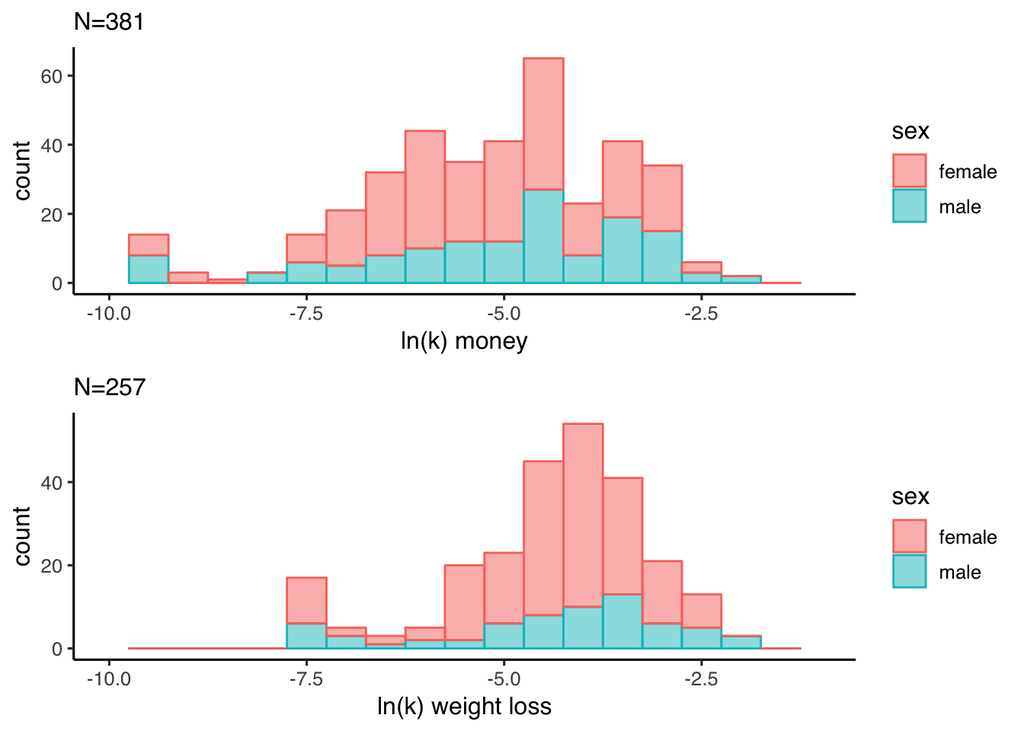

Figure 2.1: Stacked histrograms of discount rates for money (top) and weight loss (bottom)

```r
hist_money <- ggplot(data, aes(x=logk_money, fill=sex, color=sex)) +
  geom_histogram(binwidth=0.5, position="stack", alpha=0.5) +
  xlim(-10, -1) +
  apatheme +
  labs(x="ln(k) money", subtitle = n_all)

hist_weight <- ggplot(data, aes(x=logk_weight, fill=sex, color=sex)) +
  geom_histogram(binwidth=0.5, position="stack", alpha=0.5) +
  xlim(-10, -1) +
  apatheme +
  labs(x="ln(k) weight loss", subtitle = n_iiwl)

ggarrange(hist_money, hist_weight, ncol=1, nrow=2)
```

## 2.3 Discounting for money versus weight loss

Figure 2.2 shows the joint distribution of discount rates for money and weight loss. A Bayesian 1-tailed test for a positive correlation between discount rate types shows decisive evidence for a positive correlation ($BF_{+0}=27,628$). However the effect size is small, with only around 9% of shared variance, $R^2$ = 0.091 (95% CI: 0.034, 0.166) (see `discounting money vs weight.jasp`).

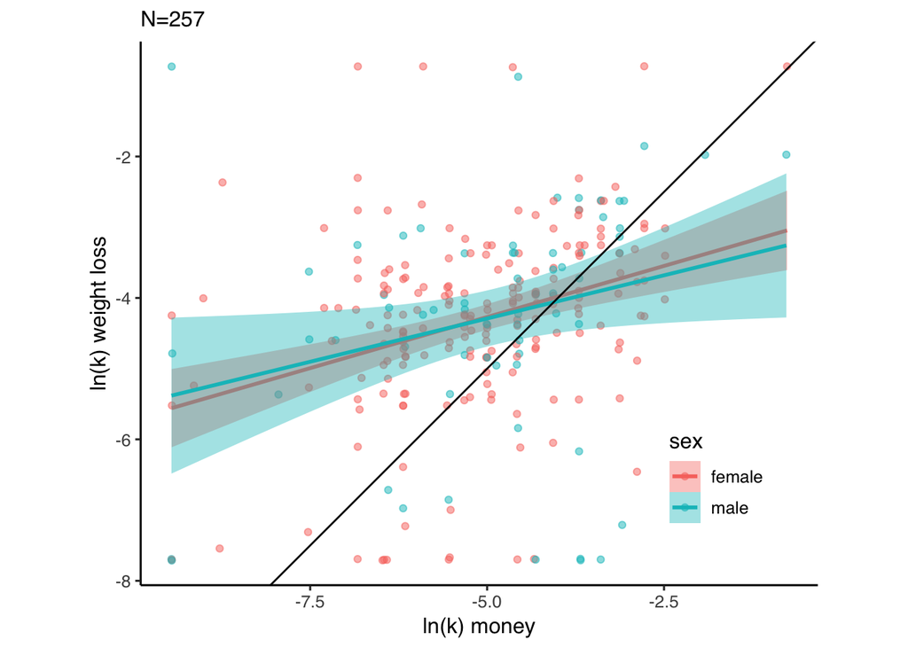

Figure 2.2: Joint distribution between discount rates for money and weight loss. People falling along the diagonal discount money and weight loss at the same amount. We cannot say anything about the exchange rate between weight loss and money because we did not do a cross-commodity discounting test.

```r
lnk_by_type <- ggplot(data_iiwl, aes(x=logk_money, y=logk_weight, color=sex)) +
  geom_point(alpha=0.5) +
  geom_smooth(method=lm, aes(fill=sex)) +
  geom_abline(intercept = 0, slope = 1) +
  coord_fixed(ratio = 1) +
  labs(x="ln(k) money", y="ln(k) weight loss", subtitle = n_iiwl) +
  apatheme +
  theme(legend.position = c(0.85, 0.2))

lnk_by_type
```

```r
ggsave(file.path("figs/lnk_by_type.pdf"),
       plot = lnk_by_type)
```

There was no evidence of a different relationship for males and females. We ran a Bayesian ANCOVA to predict `logk_money`, with `sex` as a fixed factor and `logk_weight` as a predictor. We also explored if there was an interaction between sex and discounting for weight loss, and so the full model considered was `logk_money ~ logk_weight + sex + logk_weight:sex`. The best account of the data was given by `logk_money ~ logk_weight`. Adding in a main effect of `sex` is 4 times worse than the best model, counting as substantial evidence against a main effect of `sex`. The evidence against the remaining models is even stronger.

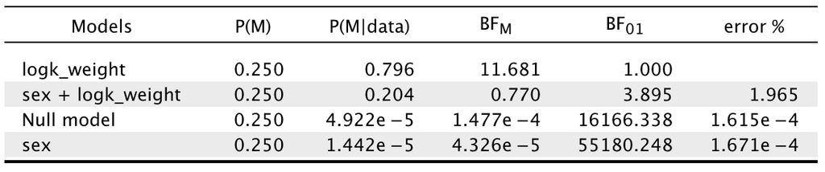

### 2.3.1 Predictors of money/weight loss discounting ratio?

However, it is interesting that there are people who discount money at a faster rate than weight loss and people who discount weight loss at a faster rate than money. This raises the interesting question of whether there is a relationship between the ratio of discount rates and BMI or age. Visually, there is no compelling relationship between either age or BMI and the ratio of the discount rates (see Figure 2.3).

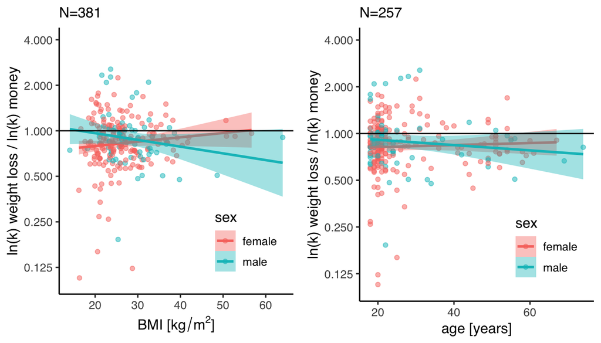

Figure 2.3: Visualisation of any relationship between BMI and age on the ratio of discounting weight loss and money.

```r
data_iiwl$kratio <- data_iiwl$logk_weight / data_iiwl$logk_money

bmi_kratio <- ggplot(data_iiwl, aes(x=bmi, y=kratio, colour=sex)) +
  geom_point(alpha=0.5) +
  geom_smooth(method='lm', aes(fill=sex)) +
  geom_abline(intercept = 0, slope = 0) +
  apatheme +
  scale_y_continuous(limits=c(0.1, 4),
                     trans='log',
                     breaks=c(0.125, 0.25, 0.5, 1, 2, 4)) +
  labs(x=expression(paste("BMI [", kg/m^2, "]")),
       y="ln(k) weight loss / ln(k) money",
       subtitle=n_all) +
  theme(legend.position = c(0.8, 0.2))

age_kratio <- ggplot(data_iiwl, aes(x=age, y=kratio, colour=sex)) +
  geom_point(alpha=0.5) +
  geom_smooth(method='lm', aes(fill=sex)) +
  geom_abline(intercept = 0, slope = 0) +
  apatheme +
  scale_y_continuous(limits=c(0.1, 4),
                     trans='log',
                     breaks=c(0.125, 0.25, 0.5, 1, 2, 4)) +
  labs(x="age [years]",
       y="ln(k) weight loss / ln(k) money",
       subtitle=n_iiwl) +
  theme(legend.position = c(0.8, 0.2))

ggarrange(bmi_kratio, age_kratio, ncol=2, nrow=1)
```

We ran a Bayesian ANCOVA with the discount rate ratio as the outcome variable. We included `sex` as a fixed factor, and `age` and `bmi` as covariates, and considered interactions between `sex` and `bmi` and `age`. The best model to explain the data was the null model, indicating that neither sex nor age nor bmi could predict the ratio of discount rates. The next best model was a main effect of `bmi`, however this was slightly worse than the null model at accounting for the data (BF=3.39). All other models were even worse, and so we have convincing evidence that `sex`, `age`, `bmi` or various interactions are not related to the ration between discount rates for weight loss and money.

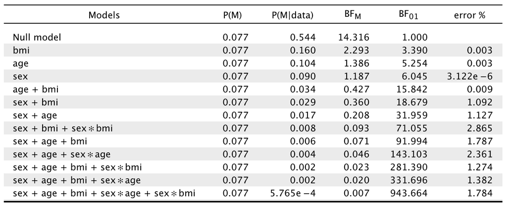

Table 2: Bayes Factors (*BF*<sub>01</sub>) are presented relative to the null model (model 0) such that positive values represent evidence *against* a given model relative to the null. See the supplementary file `ln_k_ratio.jasp`.

## 2.4 Body Mass Index

```r
severly_underweight <- sum(data$bmi<17.5)
underweight <- sum(data$bmi>=17.5 & data$bmi<18.5)
normalweight <- sum(data$bmi>=18.5 & data$bmi<25)
preobesity <- sum(data$bmi>=25 & data$bmi<30)
obese_total <- sum(data$bmi>=30)

Category <- c("Severly underweight",
              "Underweight",
              "Normal",
              "Pre-obesity",
              "Obese")
Frequency <- c(severly_underweight,
               underweight,
               normalweight,
               preobesity,
               obese_total)

bmi_cateogory_table <- tibble(Category, Frequency)
```

Figure 2.4 shows the distribution of BMI values based upon World Health Organisation categories. This positively skewed distribution is representative of the BMI distribution seen in large scale surveys (Humphreys 2000). Anorexia requires a clinical diagnosis so we classify those with BMI<17.5 as serverly underweight. Our sample contains a broad range of BMI levels, including 14 severly underweight people and 66 with obesity, of varying levels of severity. A full breakdown of BMI categories is given in the table below.

```r
bmi_cateogory_table
```

```
## # A tibble: 5 x 2
##   Category            Frequency
##   <chr>                   <int>
## 1 Severly underweight        14
## 2 Underweight                11
## 3 Normal                    210
## 4 Pre-obesity                80
## 5 Obese                      66
```

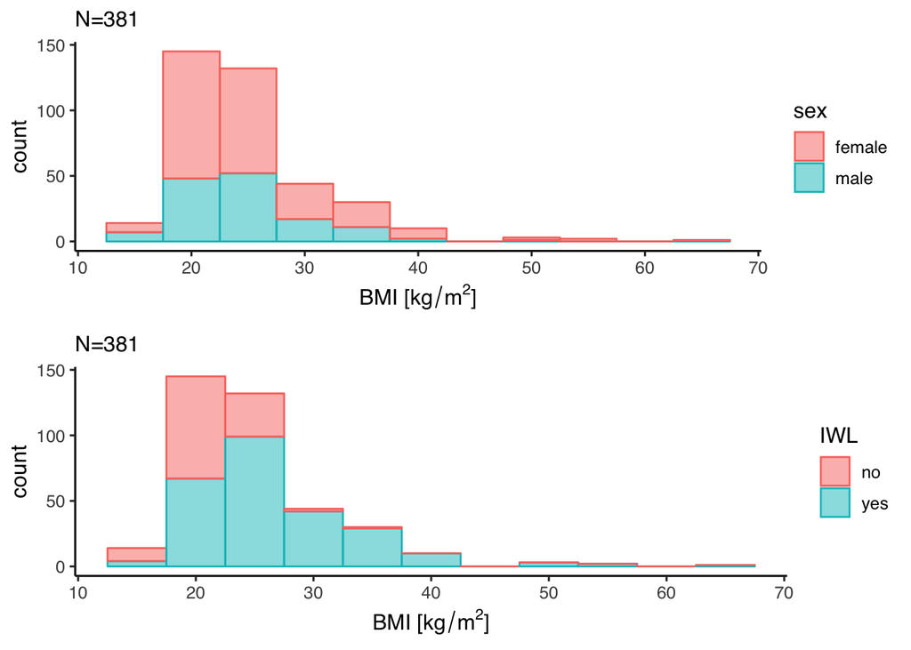

Figure 2.4: Stacked histograms of BMI of participants in our dataset by sex.

```r
bmi_all <- ggplot(data, aes(x=bmi, fill=sex, color=sex)) +
  geom_histogram(position="stack", alpha=0.5, binwidth=5) +
  apatheme +
  labs(x=expression(paste("BMI [", kg/m^2, "]")), subtitle = n_all)

bmi_iwl <- ggplot(data, aes(x=bmi, fill=IWL, color=IWL)) +
  geom_histogram(position="stack", alpha=0.5, binwidth=5) +
  apatheme +
  labs(x=expression(paste("BMI [", kg/m^2, "]")), subtitle = n_all)

ggarrange(bmi_all, bmi_iwl, ncol=1, nrow=2)
```

## 2.5 BMI by age and sex

It is known from larger scale surveys (Sutin and Ferrucci 2011) that there is a dependence of BMI upon age. This relationship is nonlinear over the entire lifespan, with decreases seen in adolescence following a rise in adult life, with a later decrease beyond the age of around 60. We decided to model the BMI and age relationship as a linear trend based on: a) this being true to a first approximation for our age range of 18-80, b) not having sufficient data at the older age range to accurately estimate a non-linear relationship. Figure 2.5 shows clear increases in BMI as a function of age.

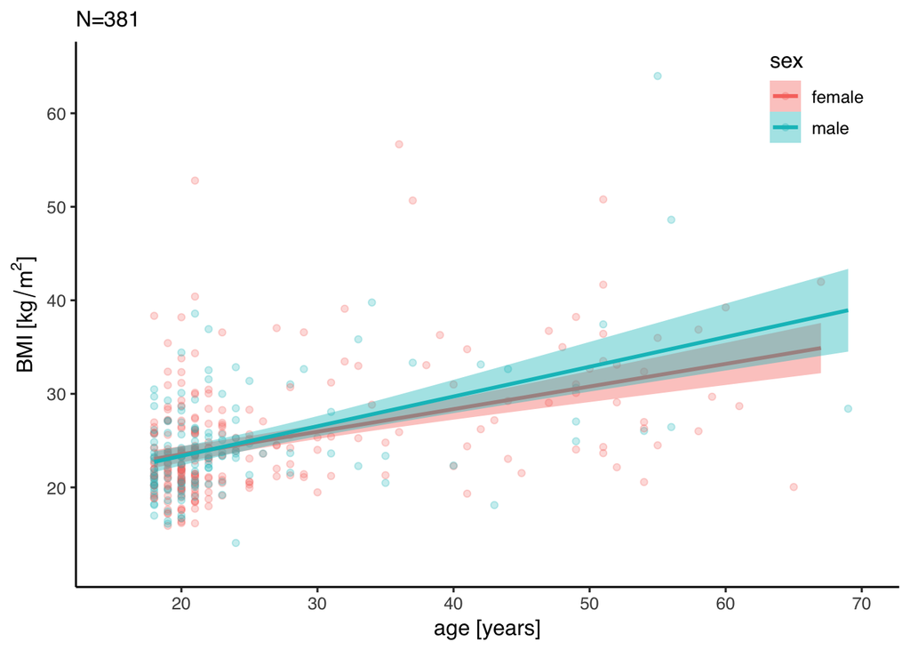

Figure 2.5: BMI by age and sex.

```r
ggplot(data=data, aes(x=age, y=bmi, colour=sex)) +
  geom_point(alpha=0.25) +
  geom_smooth(method=lm, aes(fill=sex)) +
  scale_x_continuous(limits=c(15, 70),
                     breaks=c(20, 30, 40, 50, 60, 70)) +
  scale_y_continuous(limits=c(12, 65),
                     breaks=c(20, 30, 40, 50, 60, 70)) +
  labs(x="age [years]",
       y=expression(paste("BMI [", kg/m^2, "]")),
       subtitle = n_all) +
  apatheme + theme(legend.position = c(0.9, 0.9))
```

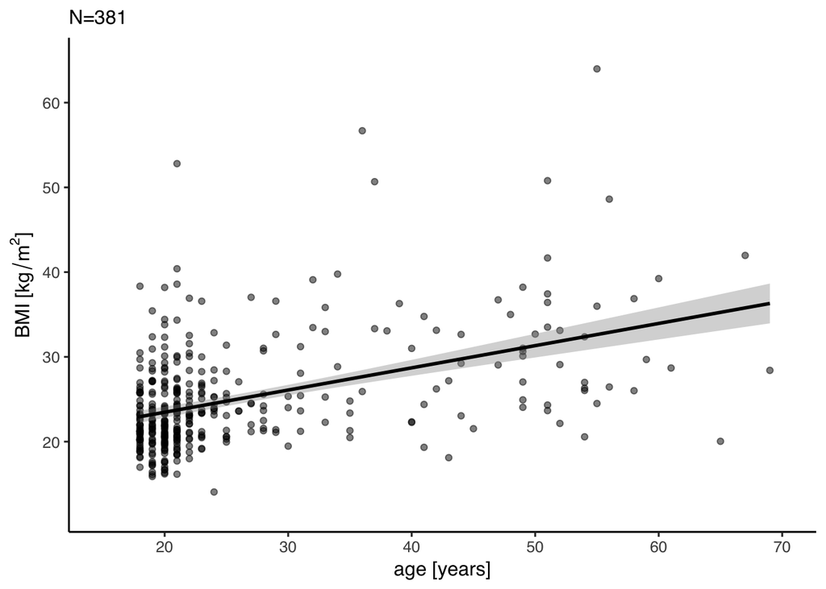

```r
bmi_age_plot <- ggplot(data=data, aes(x=age, y=bmi)) +
  geom_point(alpha=0.5) +
  geom_smooth(method=lm, colour='black') +
  scale_x_continuous(limits=c(15, 70),
                     breaks=c(20, 30, 40, 50, 60, 70)) +
  scale_y_continuous(limits=c(12, 65),
                     breaks=c(20, 30, 40, 50, 60, 70)) +
  labs(x="age [years]",
       y=expression(paste("BMI [", kg/m^2, "]")),
       subtitle = n_all) +
  apatheme + theme(legend.position = c(0.9, 0.9))

bmi_age_plot
```

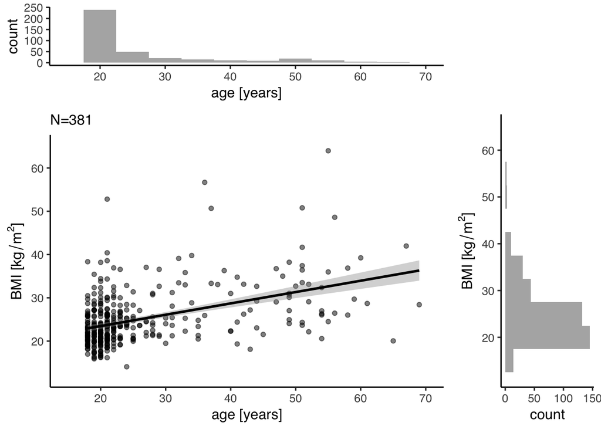

```r
# make scatter hist

hist_top <- ggplot(data, aes(x=age)) +
  geom_histogram(binwidth=5, position="stack", alpha=0.5) +
  scale_x_continuous(limits=c(15, 70),
                     breaks=c(20, 30, 40, 50, 60, 70)) +
  apatheme + theme(legend.position = "none") +
  labs(x="age [years]")

empty <- ggplot()+geom_point(aes(1,1), colour="white")+
         theme(axis.ticks=element_blank(),
               panel.background=element_blank(),
               axis.text.x=element_blank(), axis.text.y=element_blank(),
               axis.title.x=element_blank(), axis.title.y=element_blank())

scatter <- bmi_age_plot

hist_right <- ggplot(data, aes(x=bmi)) +
  geom_histogram(position="stack", alpha=0.5, binwidth=5) +
  scale_x_continuous(limits=c(12, 65),
                     breaks=c(20, 30, 40, 50, 60, 70)) +
  apatheme +
  labs(x=expression(paste("BMI [", kg/m^2, "]"))) +
  coord_flip() + theme(legend.position = "none")


bmi_age_scatterhist <- ggarrange(hist_top, empty,
                             scatter, hist_right,
                             ncol=2, nrow=2, widths=c(3, 1), heights=c(1, 3))
bmi_age_scatterhist
```

```r
# bmi_age_plot <- grid.arrange(hist_top, empty,
#                              scatter, hist_right,
#                              ncol=2, nrow=2, widths=c(4, 1), heights=c(1, 4))

ggsave(file.path("figs/bmi_age_scatterhist.pdf"),
       plot = bmi_age_scatterhist)
```

A Bayesian ANCOVA was run to examine `bmi ~ age + sex + sex:age` and all sub-models. The best model is `bmi ~ age` which had decisive evidence for the main effect of age, as compared to a null model (*BF*=2.395 * 10<sup>17</sup> ). The model including `sex` as a factor as about 8.4 times worse than this model. So there is decisive evidence for a main effect of `age` on `bmi` and substantial evidence for this relationship being the same in men and women in our dataset. Note though that this linear relationship should not necessarily be extrapolated to younger or older ages outside of our observed age range.

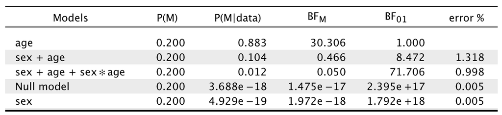

Table 3: We present Bayes Factors *BF*<sub>01</sub> relative to the best model (model 0 `bmi ~ age`) such that values *BF*<sub>01</sub> greater than 1 represent evidence *against* a given model relative to the best model. See the supplementary file `bmi and age.jasp`

## 2.6 Discounting with age

While we did not have any hypotheses about the relationship between age and discount rates, it is worthwhile to explore if there is a relationship here. Figure 2.6 shows that there are no compelling relationships between age and discounting of either money or weight loss.

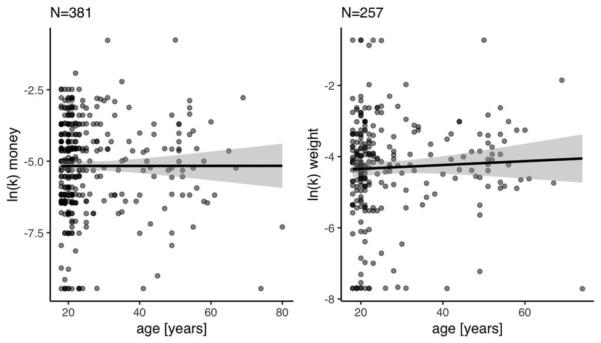

Figure 2.6: Lack of relationship between age and discount rates.

```r
money <- ggplot(data, aes(x=age, y=logk_money)) +
  geom_point(alpha=0.5) +
  geom_smooth(method='lm', colour='black') +
  geom_abline(intercept = 0, slope = 0) +
  apatheme +
  labs(x="age [years]",
       y="ln(k) money",
       subtitle=n_all) +
  theme(legend.position = c(0.8, 0.2))

weight <- ggplot(data_iiwl, aes(x=age, y=logk_weight)) +
  geom_point(alpha=0.5) +
  geom_smooth(method='lm', colour='black') +
  geom_abline(intercept = 0, slope = 0) +
  apatheme +
  labs(x="age [years]",
       y="ln(k) weight",
       subtitle=n_iiwl) +
  theme(legend.position = c(0.8, 0.2))

ggarrange(money, weight, ncol=2, nrow=1)
```

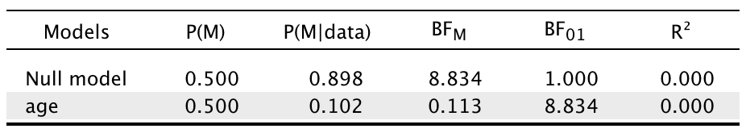

Table 4: Linear models of logk_money with age as a predictor. Bayes Factors *BF*<sub>01</sub> are presented relative to the null model (Model 0), such that values of $BF_{01}>1$ mean evidence against age as a main effect. See `discounting_age.jasp`.

Similarly, when predicting $\ln(k_{weight})$, the data was most likely under the null model, and was 5.6 times less likely with a main effect of age (*BF*<sub>01</sub>=5.606).

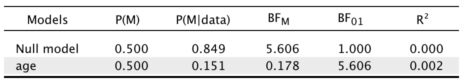

Table 5: Linear models of logk_weight with age as a predictor. Bayes Factors *BF*<sub>01</sub> are presented relative to the null model (Model 0), such that values of $BF_{01}>1$ mean evidence against age as a main effect. See `discounting_age.jasp`.

# 3 Does discounting predict BMI?

## 3.1 Correlations between discounting and BMI

Many previous studies report correlation coefficients between discount rates and BMI. This is an entirely reasonable analysis to run, but in the next section we argue that future studies need to go further than this. But here we simply ask, what is the correlation between discounting and BMI. Figure 3.1 explores this visually.

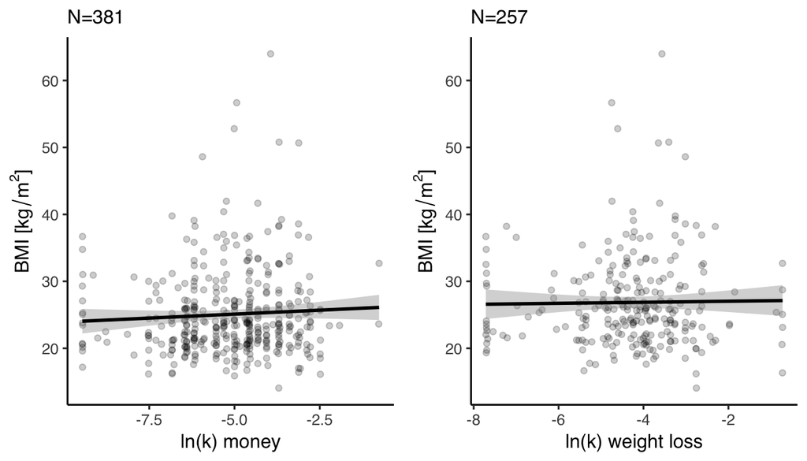

Figure 3.1: Lack of relation between bmi and discounting. This lack of relationship holds for discounting of money (left column) and of weight loss (right column).

```r
money_bmi <- ggplot(data, aes(logk_money, bmi)) +
  geom_point(alpha=0.2) +
  geom_smooth(method='lm', colour='black') +
  apatheme +
  labs(y=expression(paste("BMI [", kg/m^2, "]")),
       x="ln(k) money",
       subtitle=n_all)

weight_bmi <- ggplot(data_iiwl, aes(logk_weight, bmi)) +
  geom_point(alpha=0.2) +
  geom_smooth(method='lm', colour='black') +
  apatheme +
  labs(y=expression(paste("BMI [", kg/m^2, "]")),
       x="ln(k) weight loss",
       subtitle=n_iiwl)

bmi_discounting <- ggarrange(money_bmi, weight_bmi, ncol=2, nrow=1)

bmi_discounting
```

```r
ggsave(file.path("figs/bmi_discounting.pdf"),
       plot = bmi_discounting)
```

A Bayesian regression `bmi ~ logk_money + logk_weight + logk_money:logk_weight` showed that there were no main effects nor an interaction of discount rates. That is, a null intercept only model was the best model. There was significant evidence against the next best model (a main effect of `logk_money`). In other words, we find significant evidence against either discount rate playing a role in BMI.

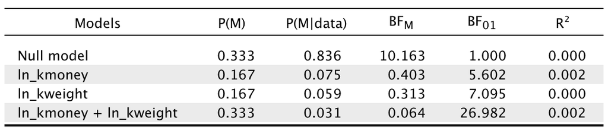

Table 6: Does discounting predict bmi? We present Bayes Factors as *BF*<sub>01</sub> relative to the null model (model 0), such that values of *BF*<sub>01</sub> greater than one represent evidence against a given model relative to the null model. See `does discounting predict bmi.jasp`.

We ran a Bayesian correlation to test the hypothesis that there is a correlation between discount rates for money and BMI (see `does discounting predict bmi.jasp`). We found substantial evidence against the hypothesis *BF*<sub>01</sub>=7.997, meaning the data is about 8 times more probable under the null hypothesis. The median Pearson correlation coefficient was R=0.059 [95% CI: -0.041, 0.158].

We ran a Bayesian correlation to test the hypothesis that there is a correlation between discount rates for weight loss and BMI (see `does discounting predict bmi.jasp`). We found strong evidence against the hypothesis *BF*<sub>01</sub>=12.391, meaning the data is about 12 times more probable under the null hypothesis. The median Pearson correlation coefficient was R=0.016 [95% CI: -0.106, 0.137].

## 3.2 Adjusting for age

We argue that if the goal is to assess the role of discounting in BMI, then it is critical to account for age. Failing to do this could mean that studies with different participant age distributions would come to different conclusions. As we know from previous work, BMI varies as a function of age (Sutin and Ferrucci 2011). Figure 2.5 clearly shows this in our dataset.

What does accounting for age actually mean? If we were to find a main effect of discounting even after removing variance accounted for by age, then this would be evidence that discount rates were predictive of BMI. In other words, it would mean that BMI increases with age, but for a given age those who discount at a higher rate would have a higher BMI.

We ran a Bayesian ANOVA, the outcome variable was `bmi`. Covariates were `age`, `logk_money` and `logk_weight`. The best model was `bmi ~ age`. The fact that all other models have $BF_{10}<1$ (i.e. $BF_{01}>1$) means that adding additional main effects (`logk_money` and/or `logk_weight`) make the data less likely relative to the `bmi ~ age` model. We have anecdotal evidence against a main effect of `logk_money` *or* `logk_weight`, and moderate evidence against both main effects of `logk_money` *and* `logk_weight`.

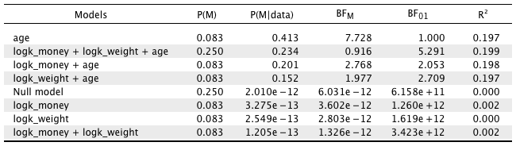

We did not include the interaction terms `logk_money:age` or `logk_weight:age` as this would amount to a moderation analysis. We reserve this for evaluation of our ‘rate of gain’ hypothesis - this was undertaken (in Python code). Those results are reported in the main paper as well as the corresponding Python code in the online Supplementary Material.

## 3.3 Summary

# 4 Analysis of Stunkard ratings

As well as the objective BMI measure, we also measured the participants subjective belief about their body size via the Stunkard Figure Rating Scale (Stunkard, Sørensen, and Schulsinger 1983).

## 4.1 BMI and Stunkard ratings

Figure 4.1 shows the relationship between BMI and Stunkard score. The Stunkard score is bounded between 1-9, and the Stunkard score saturates in a non-linear manner at very high BMI levels. That is, we seem to have a slight ceiling effect which is causing this subtle non-linear relationship. We fitted this with the function $stunkard = 9 \cdot (1-\exp(-(BMI+BMI_0)/\tau))$, where $\tau$ controls the steepness of the function and $BMI_0$ shifts the function along the x-axis.

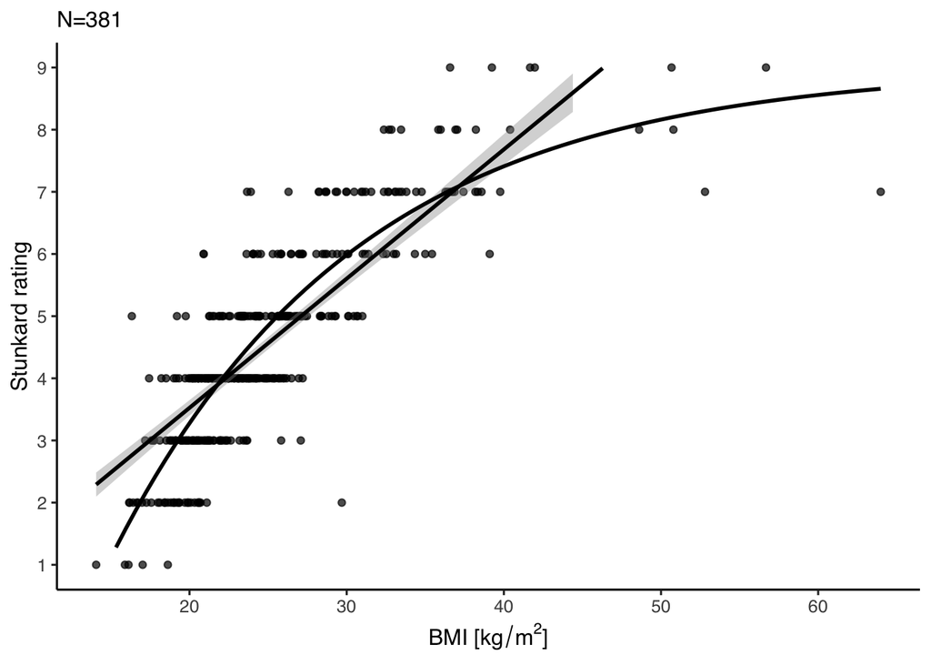

Figure 4.1: The relationship between BMI and Stunkard score. We show both a linear and a nonlinear fit (see text).

```r
ggplot(data, aes(x=bmi, y=stunkard)) +
  geom_point(alpha=0.7)+
  geom_smooth(method='lm', color='black') +
  geom_smooth(method = "nls",
              formula = y ~ ifelse(x>x0, 9*(1-exp(-(x+x0)/tau)), 1),
              method.args = list(start=c(tau=50, x0=18)),
              se=FALSE, fullrange=TRUE, color='black') +
  #scale_x_continuous(limits=c(0,65)) +
  scale_y_continuous(limits=c(1,9), breaks=c(1, 2, 3, 4, 5, 6, 7, 8, 9)) +
  apatheme +
  labs(x=expression(paste("BMI [", kg/m^2, "]")),
       y="Stunkard rating",
       subtitle = n_all)
```

## 4.2 Does discounting predict subjective weight category?

We now test whether discounting (of either type) can predict subjective body image as measured by the Stunkard scale.

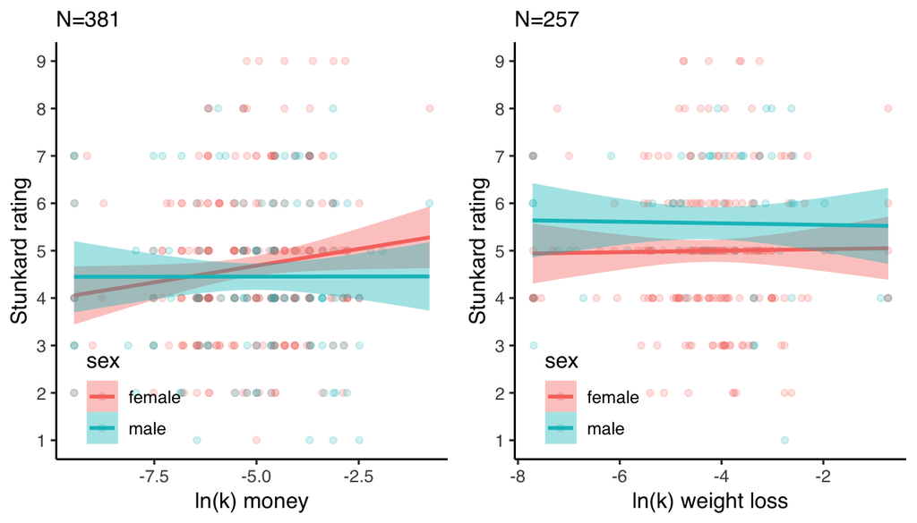

Figure 4.2: Stunkard rating as a function of discount rates.

```r
money_stunkard <- ggplot(data, aes(logk_money, stunkard, color=sex)) +
  geom_point(alpha=0.2) +
  geom_smooth(method='lm', aes(fill=sex)) +
  #stat_smooth(method = "glm", family = "binomial") +
  apatheme +
  labs(y="Stunkard rating",
       x="ln(k) money",
       subtitle=n_all)+
  theme(legend.position="bottom") +
  theme(legend.position = c(0.20, 0.15)) +
  scale_y_continuous(limits=c(1,9), breaks=c(1, 2, 3, 4, 5, 6, 7, 8, 9))

weight_stunkard <- ggplot(data_iiwl, aes(logk_weight, stunkard , color=sex)) +
  geom_point(alpha=0.2) +
  geom_smooth(method='lm', aes(fill=sex)) +
  #stat_smooth(method = "glm", family = "binomial") +
  apatheme +
  labs(y="Stunkard rating",
       x="ln(k) weight loss",
       subtitle=n_iiwl) +
  theme(legend.position="bottom") +
  theme(legend.position = c(0.20, 0.15)) +
  scale_y_continuous(limits=c(1,9), breaks=c(1, 2, 3, 4, 5, 6, 7, 8, 9))

ggarrange(money_stunkard, weight_stunkard, ncol=2, nrow=1)
```

```r
# remake stunkard figures, but no colour by sex
money_stunkard <- ggplot(data, aes(logk_money, stunkard)) +
  geom_point(alpha=0.2) +
  geom_smooth(method='lm', colour='black') +
  apatheme +
  labs(y="Stunkard rating",
       x="ln(k) money",
       subtitle=n_all)+
  theme(legend.position="bottom") +
  theme(legend.position = c(0.20, 0.15)) +
  scale_y_continuous(limits=c(1,9), breaks=c(1, 2, 3, 4, 5, 6, 7, 8, 9))

weight_stunkard <- ggplot(data_iiwl, aes(logk_weight, stunkard)) +
  geom_point(alpha=0.2) +
  geom_smooth(method='lm', colour='black') +
  apatheme +
  labs(y="Stunkard rating",
       x="ln(k) weight loss",
       subtitle=n_iiwl) +
  theme(legend.position="bottom") +
  theme(legend.position = c(0.20, 0.15)) +
  scale_y_continuous(limits=c(1,9), breaks=c(1, 2, 3, 4, 5, 6, 7, 8, 9))

# make combined figure
bmi_stunkard_discounting <- ggarrange(money_bmi, weight_bmi,
                                      money_stunkard, weight_stunkard,
                                      ncol=2, nrow=2)
ggsave(file.path("figs/bmi_stunkard_discounting.pdf"),
       plot = bmi_stunkard_discounting)
```

A visual inspection (see Figure 4.2) does not reveal any compelling linear relationships. We conducted Bayesian ANCOVA with `stunkard` as our outcome variable, `sex` as a fixed factor, and `logk_money` and `logk_weight` as covariates. The null model was the best model, suggesting none of our variables could predict the SFRS score. There is however some scope for a relationshion here, which might be elucidated in future studies. The Bayes Factors for the next best model only provide anecdotal evidence against a role for sex and discount rates and possibly an interaction between sex and discount rates.

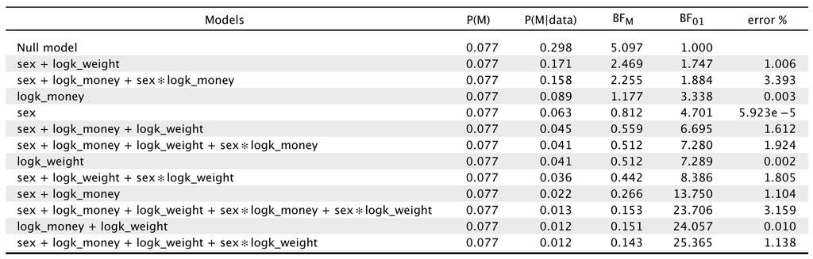

Table 8: Any predictors of Stunkard scores? We present Bayes Factors *BF*<sub>01</sub> relative to the best (which is also the null model, model 0) such that values of *BF*<sub>01</sub> greater than 1 represent evidence *against* a given model. See `stunkard.jasp`.

# References

Humphreys, Mark. 2000. “Changes in the distribution of body mass index of adults and children in the US population,” June, 1–12.

Stunkard, A J, T Sørensen, and F Schulsinger. 1983. “Use of the Danish Adoption Register for the study of obesity and thinness.” *Research Publications - Association for Research in Nervous and Mental Disease* 60: 115–20.

Sutin, A R, and L Ferrucci. 2011. “Personality and Obesity across the Adult Lifespan.” *Journal of Personality and Social Psychology* 101 (3): 579–92.